# Project Report

Owen Suelflow, Jonah Klein-Collins, Ethan Caldecott, Harry Cheng

2022-12-12

## Introduction

When watching an NBA game as a spectator, it can often be straightforward when attempting to discern which teams are better than others. However, it can be difficult to understand what causes a team to win games and put itself above its competitors. Although the scoreboard gives fans a simple analysis of which team is better, there are many processes behind the scenes that contribute to a team’s success: the general manager must construct a roster capable of winning games and the coach must develop a play-style that maximizes the talent of the players, making the team greater than the sum of its parts. This report will examine NBA (National Basketball Association) play style and roster construction to try and answer the following questions: What tendencies and characteristics do playoff teams exhibit compared to less successful teams? What patterns begin to emerge? The data for our analysis was scraped directly from NBA.com and downloarded from basketball-reference.com and pertains to the 2021-22 and 2022-23 NBA seasons. The code to acquire this data can be easily accessed in the appendix at the end of this report.

One of the difficulties we encountered when exploring the data is the idea of reverse causality, or the concept that multiple statistics might influence each other when being compared. For example, comparing point differential among NBA teams, meaning the difference between the average points scored and points given up, and the number of wins each team had. This would show us a clear trend of teams with a higher point differential having more wins. However, by definition a win occurs when a team scores more points than its opponent, so both of out variables in this scenario depend on each other. These are the types of conclusions we strove to avoid.

The nice thing about play style in the NBA is that different teams have different philosophies regarding how they play. We wanted to look at data that showed a “choice” a team made on how to play. For example, a team can choose to take more drives during a game. On the other hand, a team could decide to avoid driving into the paint and place more of an emphasis on shooting 3 point shots. These types of data do not have reverse causality with wins.

For roster construction, the line regarding reverse causality is a bit more blurred. Teams may not have a choice between two options when building a team; depending on if a team is contending or rebuilding, they will likely have only one path to follow. However, it is still important to look at roster construction as a tool to follow how teams are doing. We can see if a team that is contending is actually where it should be, or if they should consider pivoting into a rebuild.

## Shiny App

To begin, we performed exploratory data analysis using a shiny app. The app only focused on play style data from eight different data sets, each focusing on one aspect of a game.

We were able to choose which data set to look at, and then choose a variable to plot against team wins. This way, we could see if there were any variables with a strong correlation to winning. Here is a link to the shiny app:

https://rstudio-connect.macalester.edu/content/ce590312-5b40-4e4c-84a9-30ff6e7b5a56

## Playstyle Analysis

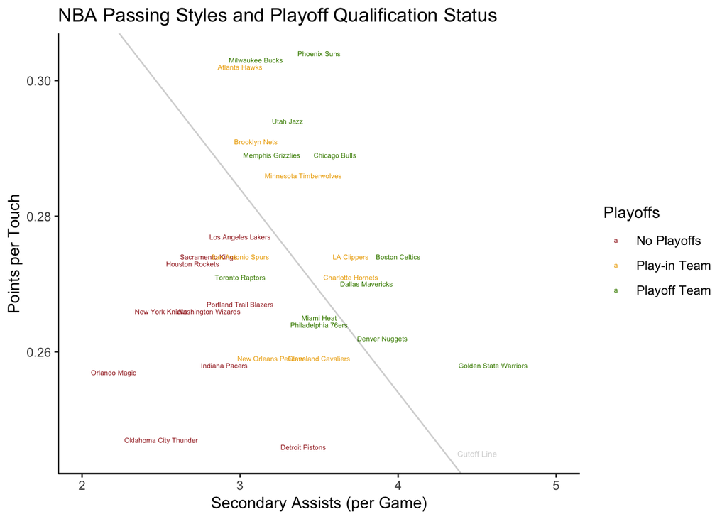

When diving into the analysis of team play-styles, it is clear that playoff teams with a lot of success just… play better. As seen in the visualization above, teams that qualify for the playoffs or play-in tournament have higher points per touch (PPT) and more secondary assists per game. While points per touch might be correlated with a team’s scoring and therefore wins (as teams that score more points than their opponent win games), it offers more insight into a team’s play style and ability to pass the ball. Another way to view PPT is how many players touch the ball per basket made, so teams who move the ball more will have fewer PPT and those that rely heavily on isolation will have higher magnitudes. Secondary assists, which also might be known coloquially as “hockey” assists, are the act of a player passing to the teammate which ultimately generates the assist - it is indicative of great teamwork and a team’s ability to move the ball around, thus associated with fewer points per touch. While it is not take a data scientist to explain that teams that win more basketball games play better, the manner in which teams play can be explored with the statistics above. The idea that playoff teams have consistently better PPT and more secondary assists suggests that playoff teams either specialize in their tactical strengths or are able to adapt to keep the opposing defense on its toes. This graph highlights difference in play-styles that are effectively captured by this analysis, as an avid basketball nerd could explain. The Golden State Warriors are well-known for their three-point shooting, movement off the ball, and quick passing. To no surprise, they exhibit the most secondary assists per game. Conversely, the Milwaukee Bucks have garnered respect around the league through their isolation play-style, which allows Giannis Antetokounmpo, the best player in the world, to run downhill towards the basket and decimate teams by taking on players one-by-one. Again, to no surprise, this analysis effectively captures their success in isolation, as they are second to only the Phoenix Suns in points-per-touch.

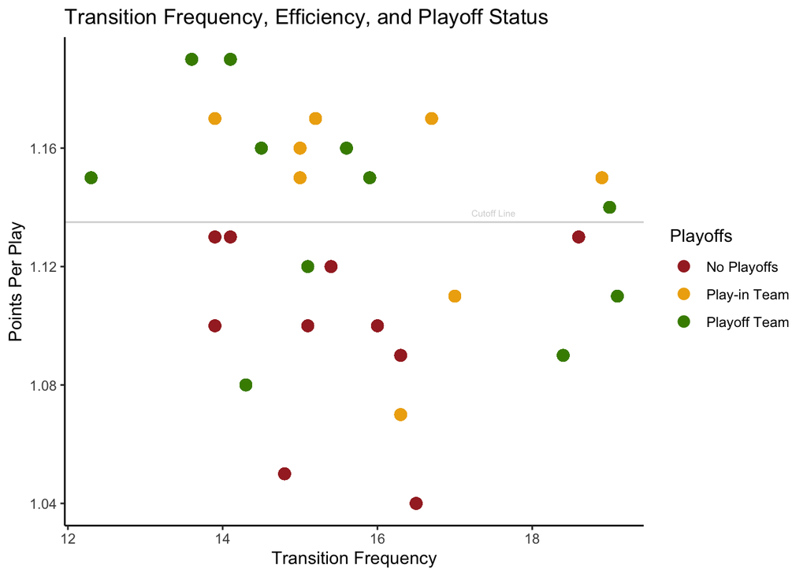

Another analysis that might explain the difference between poor and great teams in the NBA is taking closer look at a team’s ability to convert buckets in transition. After forcing a turnover, basketball teams often foam at the mouth for an open opportunity down the court, quickly exploiting the space left open in transition. However, there does not seem to be any sort of pattern in the frequency of which teams try to push the ball in transition, as there are playoff teams that do not like to run in transition and teams that do. Fortunately, there is one key finding – good teams are efficient in transition. Despite differences in transition frequency, playoff teams and teams that make the play-in tournament are exceptional at capitalizing on the fast break with higher transition points-per-play, punishing opponents for giving them an opportunity to score easy points.

While there is not a correlation between having lots of transition opportunities and winning, there are other hustle-related statistics that do show a positive correlation to winning. The visualization below shows that playoff/play-in teams tend to win more loose balls and execute more box outs per game than teams who did not make the playoffs. Another interesting trend that we noticed was that a lot of the teams that performed well in these statistics were older. The Miami Heat, for example are one of the oldest teams in the NBA, yet they led the league in box outs. This trend shows up throughout the plot. It could be because older teams are more experienced and generally of higher quality, as we will show later on. These teams know what it takes to win, and oftentimes that means honing in on the smaller details of the games. On the flip side, younger teams generally lose more games, and they aren’t disciplined enough to hustle after loose balls or get a body on somebody and get a rebound. Furthermore, these young teams don’t have the chemistry and team culture like a team such as the Miami Heat. Overall, it is clear that winning teams prioritize hustle and sound defense, and that experienced teams know these things are crucial to win games in the NBA.

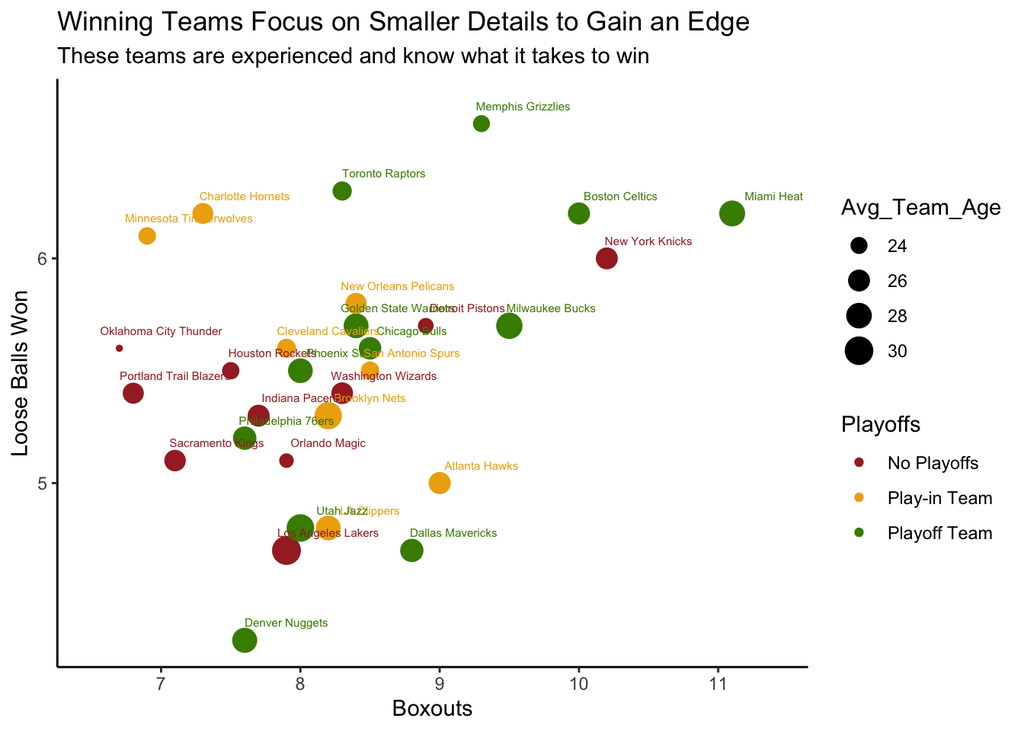

## Roster Contstruction

For the next two plots, data was downloaded from basketball-reference.com, a leading NBA statistics site that has lots of useful data for answering our research question.

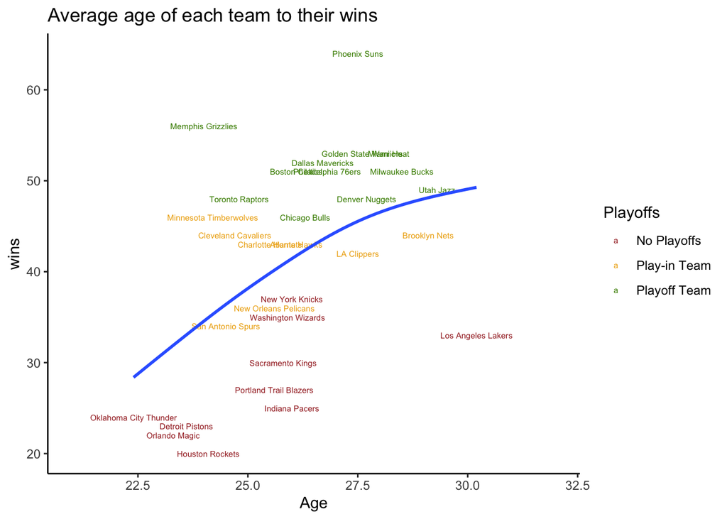

The manner in which an NBA team constructs its roster is very important to its performance. The average age of NBA players across the league is about 26 years old. However, the average age of teams ranges from 22 to 30 years old, which is 8 years of difference. From this graph, it can be seen that the older an average age of a team gets, the more wins it gets. The reason is because the younger teams lack experience: they have only entered the NBA for only a few years and have played fewer games compared to older players. Take the Oklahoma City Thunder for example: the Thunder have traded a lot of their older players and are currently undergoing a rebuild, hoping to replenish their talent in the draft. Because of this, their team is younger and unaccustomed to the NBA’s physicality and pace, and their immaturity might restrict chemistry with their teammates. A standout in this visualization is the Memphis Grizzlies, which is a very young team with an average age of about 24 years old but with the second most wins in the NBA. Even though it’s a young team, their players, such as Ja Morant, have leadership qualities that enhance their ability to work together. We can tell that the Grizzlies have much potential and would be a strong contender for the championship for the years to come. The best age range for NBA teams is between 25-30 years old. The teams that are in this age range have already played in several NBA seasons and are well-experienced. Let’s take a look at the Golden State Warriors. Although the Warriors’ average age is about 28 years old, players in the team such as Stephen Curry and Draymond Green have played in the NBA for 10+ years. They are perennial winners that have encountered many different circumstances. They have already developed good chemistry through many years as teammates, developing a championship pedigree. This is the reason why they are always championship contenders in the past few years. An outlier in this graph is the LA Lakers, which contains players of an average age of about 31 years old but didn’t win half of their games played or made the playoffs. It is probably because they performed bad trades during the offseason that messed up their chemistry while crucial players such as Lebron James and Anthony Davis got injured. The Lakers supposedly could get better next year when their injured players recover and are available to play after developing improved chemistry.

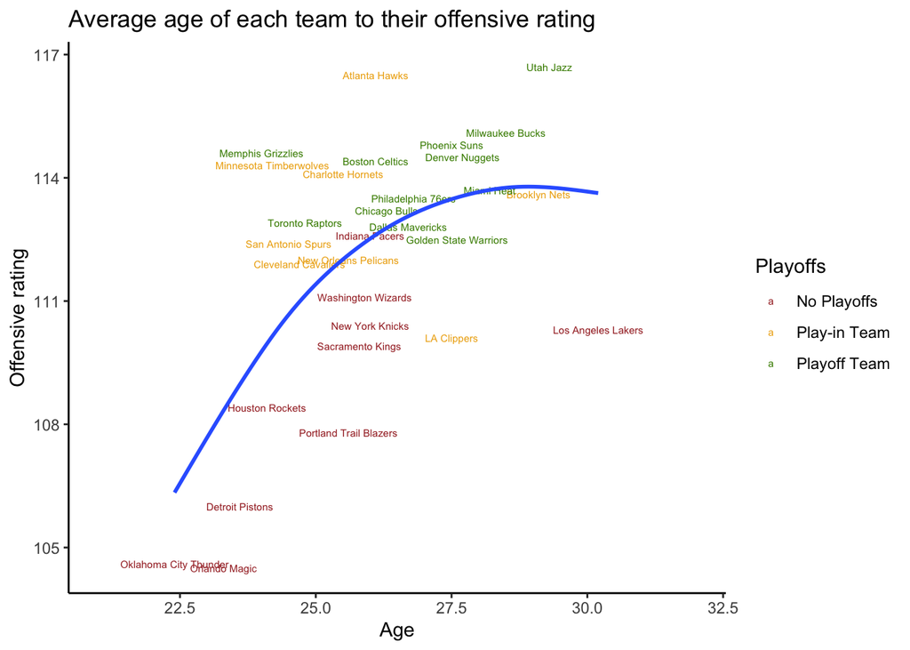